# Reproducibility

## Background

Using devices such as Jawbone Up, Nike FuelBand, and Fitbit it is now possible to collect a large amount of data about personal activity relatively inexpensively. These type of devices are part of the quantified self movement – a group of enthusiasts who take measurements about themselves regularly to improve their health, to find patterns in their behavior, or because they are tech geeks. One thing that people regularly do is quantify how much of a particular activity they do, but they rarely quantify how well they do it. In this project, your goal will be to use data from accelerators on the belt, forearm, arm, and dumbbell of 6 participants. They were asked to perform barbell lifts correctly and incorrectly in 5 different ways. More information is available from the website here: http://web.archive.org/web/20161224072740/http:/groupware.les.inf.puc-rio.br/har (see the section on the Weight Lifting Exercise Dataset).

## Data

The training data for this project are available here:

https://d396qusza40orc.cloudfront.net/predmachlearn/pml-training.csv

The test data are available here:

https://d396qusza40orc.cloudfront.net/predmachlearn/pml-testing.csv

The data for this project come from this source: http://web.archive.org/web/20161224072740/http:/groupware.les.inf.puc-rio.br/har. If you use the document you create for this class for any purpose please cite them as they have been very generous in allowing their data to be used for this kind of assignment.

```r
install.packages('lattice')
```

```r
install.packages('ggplot2')
install.packages('caret')
install.packages('kernlab')
install.packages('rattle')
install.packages('corrplot')
install.packages("rpart")
install.packages("rpart.plot")
install.packages('contrib.url')
library(lattice)
library(ggplot2)
library(caret)
library(kernlab)
library(rattle)
library(corrplot)
library(rpart)
library(rpart.plot)
```

```r
# Set seed for reproducability
set.seed(123)
```

## Download data

The `pml-training.csv` data is used as training data. The `pml-test.csv` data is used as test data.

```r
traincsv <- read.csv("./pml-training.csv")
testcsv <- read.csv("./pml-testing.csv")

dim(traincsv)
```

```
## [1] 19622   160
```

```r
dim(testcsv)
```

```
## [1]  20 160
```

## Data processing

In this section basic transformation has been performed to clean data and remove NA values and not relevant variables.

```r
# Cleaning the Data

traincsv <- traincsv[,colMeans(is.na(traincsv)) < .9] #removing mostly na columns
traincsv <- traincsv[,-c(1:7)] #removing metadata which is irrelevant to the outcome
```

```r
nonZeroValue <- nearZeroVar(traincsv) # Removing Variables which are having nearly zero variance
traincsv <- traincsv[,-nonZeroValue]
dim(traincsv)
```

```
## [1] 19622    53
```

```r
inTrain <- createDataPartition(y=traincsv$classe, p=0.7, list=F)
trainData <- traincsv[inTrain,]
validData <- traincsv[-inTrain,]
```

## Creating and Testing the Models

```r
control <- trainControl(method="cv", number=3, verboseIter=F)
```

## Decision Tree

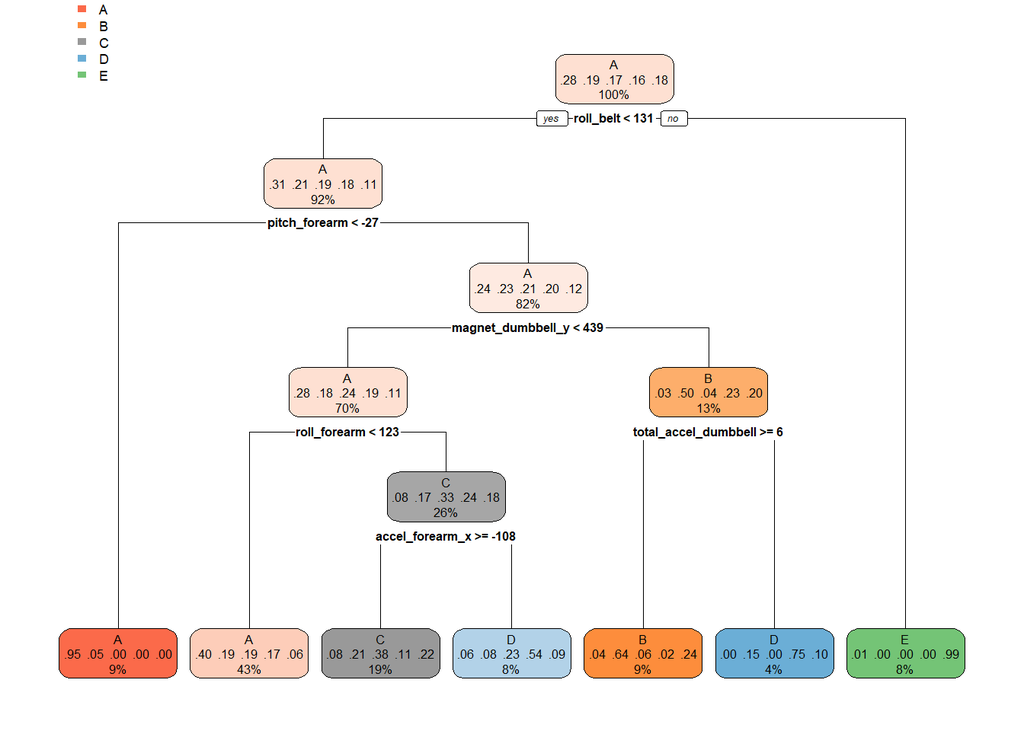

```r
trainModel <- train(classe~., data=trainData, method="rpart", trControl = control, tuneLength = 5)

rpart.plot(trainModel$finalModel) # instead of fancyRpartPlot
```

```r
predModel <- predict(trainModel, validData)
cmtrees <- confusionMatrix(predModel, factor(validData$classe))
cmtrees
```

```
## Confusion Matrix and Statistics
##
##           Reference
## Prediction    A    B    C    D    E
##          A 1530  464  469  440  144
##          B   28  361   30   13  120
##          C   87  230  427  131  246
##          D   27   84  100  380   85
##          E    2    0    0    0  487
##
## Overall Statistics
##
##                Accuracy : 0.5412
##                  95% CI : (0.5284, 0.554)
##     No Information Rate : 0.2845
##     P-Value [Acc > NIR] : < 2.2e-16
##
##                   Kappa : 0.402
##
##  Mcnemar's Test P-Value : < 2.2e-16
##
## Statistics by Class:
##
##                      Class: A Class: B Class: C Class: D Class: E
## Sensitivity            0.9140  0.31694  0.41618  0.39419  0.45009
## Specificity            0.6398  0.95976  0.85717  0.93985  0.99958
## Pos Pred Value         0.5021  0.65399  0.38091  0.56213  0.99591
## Neg Pred Value         0.9493  0.85412  0.87427  0.88789  0.88973
## Prevalence             0.2845  0.19354  0.17434  0.16381  0.18386
## Detection Rate         0.2600  0.06134  0.07256  0.06457  0.08275
## Detection Prevalence   0.5178  0.09380  0.19048  0.11487  0.08309
## Balanced Accuracy      0.7769  0.63835  0.63668  0.66702  0.72484
```

## Random Forest

```r
trainRF <- train(classe~., data=trainData, method="rf", trControl = control, tuneLength = 5)

predRF <- predict(trainRF, validData)
cmrf <- confusionMatrix(predRF, factor(validData$classe))
cmrf
```

```
## Confusion Matrix and Statistics
##
##           Reference
## Prediction    A    B    C    D    E
##          A 1674    5    0    0    0
##          B    0 1129    4    0    0
##          C    0    5 1020    9    4
##          D    0    0    2  955    4
##          E    0    0    0    0 1074
##
## Overall Statistics
##
##                Accuracy : 0.9944
##                  95% CI : (0.9921, 0.9961)
##     No Information Rate : 0.2845
##     P-Value [Acc > NIR] : < 2.2e-16
##
##                   Kappa : 0.9929
##
##  Mcnemar's Test P-Value : NA
##
## Statistics by Class:
##
##                      Class: A Class: B Class: C Class: D Class: E
## Sensitivity            1.0000   0.9912   0.9942   0.9907   0.9926
## Specificity            0.9988   0.9992   0.9963   0.9988   1.0000
## Pos Pred Value         0.9970   0.9965   0.9827   0.9938   1.0000
## Neg Pred Value         1.0000   0.9979   0.9988   0.9982   0.9983
## Prevalence             0.2845   0.1935   0.1743   0.1638   0.1839
## Detection Rate         0.2845   0.1918   0.1733   0.1623   0.1825
## Detection Prevalence   0.2853   0.1925   0.1764   0.1633   0.1825
## Balanced Accuracy      0.9994   0.9952   0.9952   0.9947   0.9963
```

From the Confusion Matrix, we can clearly see that the prediction accuracy of Random Forest model is 99% which is satisfactory.

## Gradient Boosted Trees

```r
trainGbm <- train(classe~., data=trainData, method="gbm", trControl = control, tuneLength = 5, verbose = F)

predGbm <- predict(trainGbm, validData)
cmgbm <- confusionMatrix(predGbm, factor(validData$classe))
cmgbm
```

```
## Confusion Matrix and Statistics
##
##           Reference
## Prediction    A    B    C    D    E
##          A 1670    8    0    0    2
##          B    2 1121    7    0    0
##          C    1   10 1012   10    8
##          D    0    0    7  951    5
##          E    1    0    0    3 1067
##
## Overall Statistics
##
##                Accuracy : 0.9891
##                  95% CI : (0.9861, 0.9916)
##     No Information Rate : 0.2845
##     P-Value [Acc > NIR] : < 2.2e-16
##
##                   Kappa : 0.9862
##
##  Mcnemar's Test P-Value : NA
##
## Statistics by Class:
##
##                      Class: A Class: B Class: C Class: D Class: E
## Sensitivity            0.9976   0.9842   0.9864   0.9865   0.9861
## Specificity            0.9976   0.9981   0.9940   0.9976   0.9992
## Pos Pred Value         0.9940   0.9920   0.9721   0.9875   0.9963
## Neg Pred Value         0.9990   0.9962   0.9971   0.9974   0.9969
## Prevalence             0.2845   0.1935   0.1743   0.1638   0.1839
## Detection Rate         0.2838   0.1905   0.1720   0.1616   0.1813
## Detection Prevalence   0.2855   0.1920   0.1769   0.1636   0.1820
## Balanced Accuracy      0.9976   0.9912   0.9902   0.9920   0.9927
```

```r
# Support Vector Machine
trainSvm <- train(classe~., data=trainData, method="svmLinear", trControl = control, tuneLength = 5, verbose = F)

predSvm <- predict(trainSvm, validData)
cmsvm <- confusionMatrix(predSvm, factor(validData$classe))
cmsvm
```

```
## Confusion Matrix and Statistics
##
##           Reference
## Prediction    A    B    C    D    E
##          A 1558  149  109   63   59
##          B   27  837   83   42  154
##          C   34   64  796  112   85
##          D   43   18   23  703   52
##          E   12   71   15   44  732
##
## Overall Statistics
##
##                Accuracy : 0.7861
##                  95% CI : (0.7754, 0.7965)
##     No Information Rate : 0.2845
##     P-Value [Acc > NIR] : < 2.2e-16
##
##                   Kappa : 0.7277
##
##  Mcnemar's Test P-Value : < 2.2e-16
##
## Statistics by Class:
##
##                      Class: A Class: B Class: C Class: D Class: E
## Sensitivity            0.9307   0.7349   0.7758   0.7293   0.6765
## Specificity            0.9098   0.9355   0.9393   0.9724   0.9704
## Pos Pred Value         0.8039   0.7323   0.7296   0.8379   0.8375
## Neg Pred Value         0.9706   0.9363   0.9520   0.9483   0.9302
## Prevalence             0.2845   0.1935   0.1743   0.1638   0.1839
## Detection Rate         0.2647   0.1422   0.1353   0.1195   0.1244
## Detection Prevalence   0.3293   0.1942   0.1854   0.1426   0.1485
## Balanced Accuracy      0.9202   0.8352   0.8576   0.8508   0.8235
```

# Predictions on Test Set

```r
pred <- predict(trainRF, testcsv)
print(pred)
```

```
##  [1] B A B A A E D B A A B C B A E E A B B B
## Levels: A B C D E
```

# Appendix

correlation matrix of variables in training set

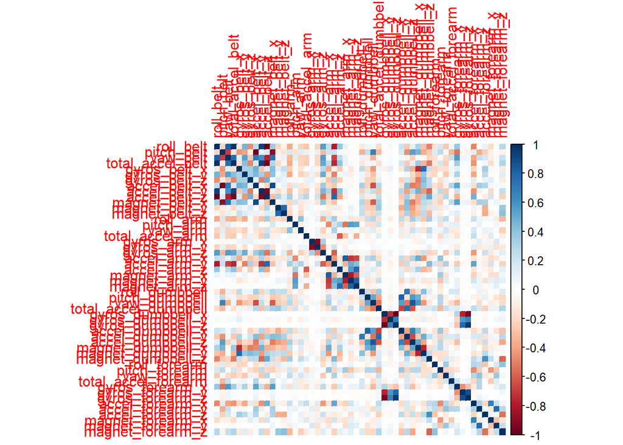

```r
corrPlot <- cor(trainData[, -length(names(trainData))])
corrplot(corrPlot, method="color")
```

# Plotting the models

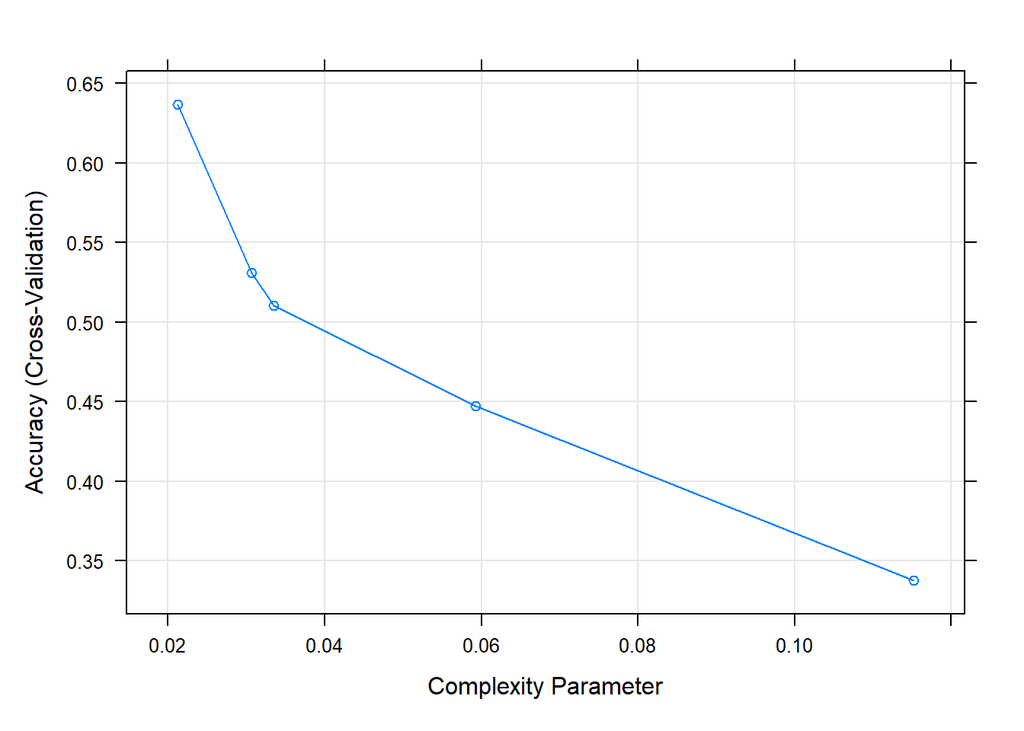

```r
plot(trainModel)
```

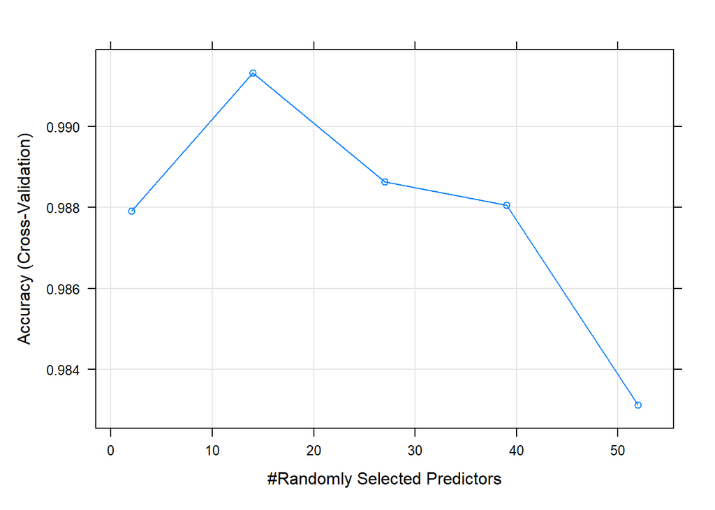

```r
plot(trainRF)
```

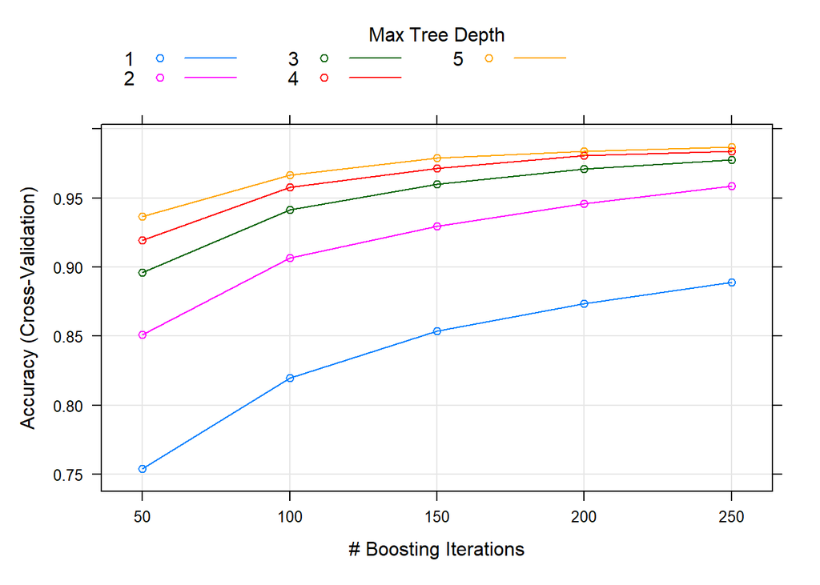

```r
plot(trainGbm)
```